# PCA (from Texas A&M University OSOS Workshop 2019)

Carl Hjelmen

8/30/2019

we’ll use the iris data set, since we have 4 continuous variables

```r
data(iris)
```

Let’s see how the data looks

```r
head(iris)
```

```
##   Sepal.Length Sepal.Width Petal.Length Petal.Width Species
## 1          5.1         3.5          1.4         0.2  setosa
## 2          4.9         3.0          1.4         0.2  setosa
## 3          4.7         3.2          1.3         0.2  setosa
## 4          4.6         3.1          1.5         0.2  setosa
## 5          5.0         3.6          1.4         0.2  setosa
## 6          5.4         3.9          1.7         0.4  setosa
```

We can see that it is 4 numerical and 1 factor, species

```r
str(iris)
```

```
## 'data.frame':    150 obs. of  5 variables:
##  $ Sepal.Length: num  5.1 4.9 4.7 4.6 5 5.4 4.6 5 4.4 4.9 ...
##  $ Sepal.Width : num  3.5 3 3.2 3.1 3.6 3.9 3.4 3.4 2.9 3.1 ...
##  $ Petal.Length: num  1.4 1.4 1.3 1.5 1.4 1.7 1.4 1.5 1.4 1.5 ...
##  $ Petal.Width : num  0.2 0.2 0.2 0.2 0.2 0.4 0.3 0.2 0.2 0.1 ...
##  $ Species     : Factor w/ 3 levels "setosa","versicolor",..: 1 1 1 1 1 1 1 1 1 1 ...
```

We’ll log transform the data to standardize the variables This is because skewness and magnitude of variables influence the PC’s. Log transformation takes care of this This is log transforming columns 1:4 (our numerical data), remember that [r,c] (R is cool). We’ll also call in the species data for later

```r
log.ir<-log(iris[,1:4])
ir.species<-iris[,5]
```

We’ll run the PCA, but set center and scale. equal to TRUE in the call to prcomp. This is not default, but advisable

```r
ir.pca<-prcomp(log.ir, center=TRUE, scale.=TRUE)
```

Let’s see the output We can see what the rotation data is for each PC for each variable

```r
print(ir.pca)
```

```
## Standard deviations (1, .., p=4):
## [1] 1.7124583 0.9523797 0.3647029 0.1656840
##
## Rotation (n x k) = (4 x 4):
##                     PC1         PC2        PC3         PC4
## Sepal.Length  0.5038236 -0.45499872  0.7088547  0.19147575
## Sepal.Width  -0.3023682 -0.88914419 -0.3311628 -0.09125405
## Petal.Length  0.5767881 -0.03378802 -0.2192793 -0.78618732
## Petal.Width   0.5674952 -0.03545628 -0.5829003  0.58044745
```

We can plot ot see how much of the variation is explained by each principal component, type is L. since it can be hard to read

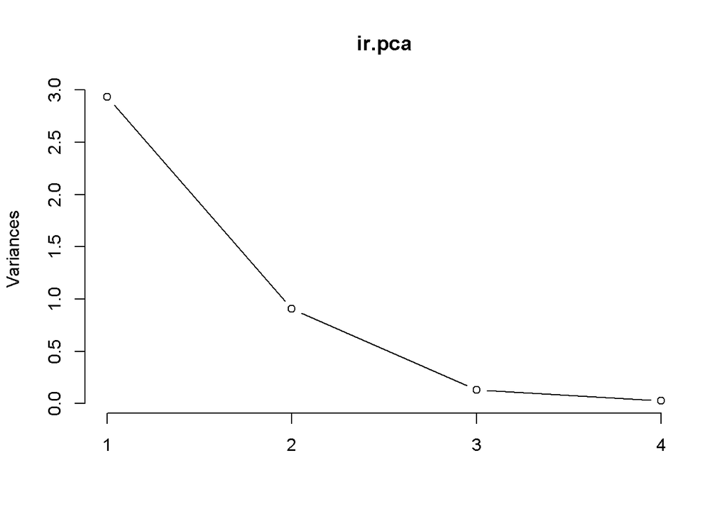

```r
plot(ir.pca, type="l")
```

most is explained by the first two PCs

summary gives us standard deviations, proportion of variance, and the cumulative variance

```r
summary(ir.pca)
```

```
## Importance of components:
##                           PC1    PC2     PC3     PC4
## Standard deviation     1.7125 0.9524 0.36470 0.16568
## Proportion of Variance 0.7331 0.2268 0.03325 0.00686
## Cumulative Proportion  0.7331 0.9599 0.99314 1.00000
```

first two PCs contributed most of it

If we want to plot it, we need to use the below. It isn’t super pretty, but we can see the separation by component the ir.pca$x[,1:2] indicates the first two columns, which are PC1 and PC2

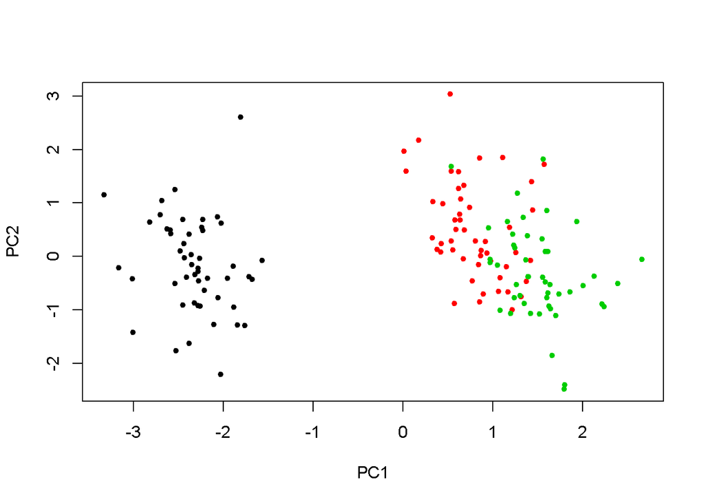

```r
plot(ir.pca$x[,1:2], pch=20, col=ir.species)
```

If we change this, we can look at other PC’s, like PC1 and 3

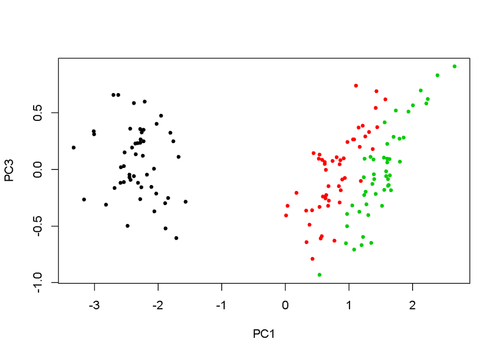

```r
plot(ir.pca$x[,c(1,3)], pch=20, col=ir.species)
```

if you want to plot it nicely, you have to install a couple packages. This can be tricky, depending on version of R you have

```r
library(devtools)
```

```r
install_github("vqv/ggbiplot")
```

```
## Skipping install of 'ggbiplot' from a github remote, the SHA1 (7325e880) has not changed since last install.
##   Use `force = TRUE` to force installation
```

```r
library(ggbiplot)
```

Then we can use a variety of things within ggplot to see the nice plot

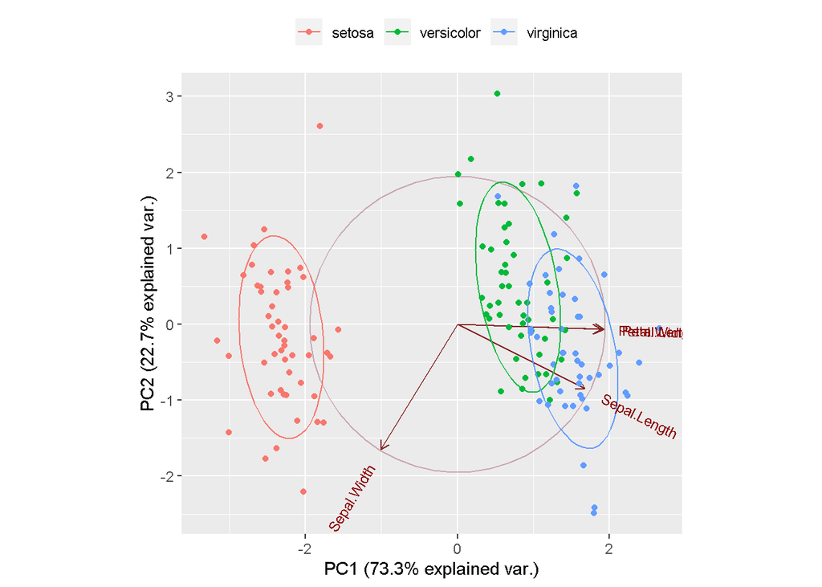

```r
g <- ggbiplot(ir.pca, obs.scale = 1, var.scale = 1,
              groups = ir.species, ellipse = TRUE,
              circle = TRUE)
g <- g + scale_color_discrete(name = '')
g <- g + theme(legend.direction = 'horizontal',
               legend.position = 'top')
print(g)
```